# exercise-10

Sam Smith

4/11/2022

Loading in tibble and plotting lifespan vs body mass for females.

```r
library(tidyverse)
```

```r
library(dplyr)
library(cowplot)
library(patchwork)
f <- "https://raw.githubusercontent.com/difiore/ada-2022-datasets/main/KamilarAndCooperData.csv"
d <- read_csv(f, col_names=TRUE)
names(d)
```

```
##  [1] "Scientific_Name"         "Family"
##  [3] "Genus"                   "Species"
##  [5] "Brain_Size_Species_Mean" "Brain_Size_Female_Mean"
##  [7] "Brain_size_Ref"          "Body_mass_male_mean"
##  [9] "Body_mass_female_mean"   "Mass_Dimorphism"
## [11] "Mass_Ref"                "MeanGroupSize"
## [13] "AdultMales"              "AdultFemale"
## [15] "AdultSexRatio"           "Social_Organization_Ref"
## [17] "InterbirthInterval_d"    "Gestation"
## [19] "WeaningAge_d"            "MaxLongevity_m"
## [21] "LitterSz"                "Life_History_Ref"
## [23] "GR_MidRangeLat_dd"       "Precip_Mean_mm"
## [25] "Temp_Mean_degC"          "AET_Mean_mm"
## [27] "PET_Mean_mm"             "Climate_Ref"
## [29] "HomeRange_km2"           "HomeRangeRef"
## [31] "DayLength_km"            "DayLengthRef"
## [33] "Territoriality"          "Fruit"
## [35] "Leaves"                  "Fauna"
## [37] "DietRef1"                "Canine_Dimorphism"
## [39] "Canine_Dimorphism_Ref"   "Feed"
## [41] "Move"                    "Rest"
## [43] "Social"                  "Activity_Budget_Ref"
```

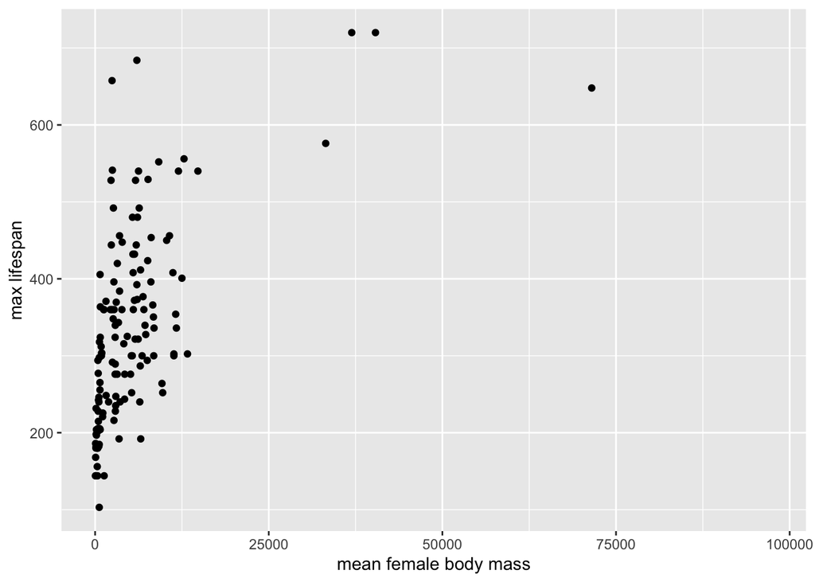

```r
ggplot(d,aes(x=Body_mass_female_mean,y=MaxLongevity_m)) + geom_point(na.rm=TRUE) + ylab("max lifespan") +
  xlab("mean female body mass")
```

The relationship does not look linear at all. Seems like for every unit change in mean female body mass at low masses, there is a relatively big change in lifespan, but it flattens out as you get to larger body masses. It would probably be useful to log transform one or both of these variables.

First, plotting to see whether the relationship looks better after log transforming one or both of the variables.

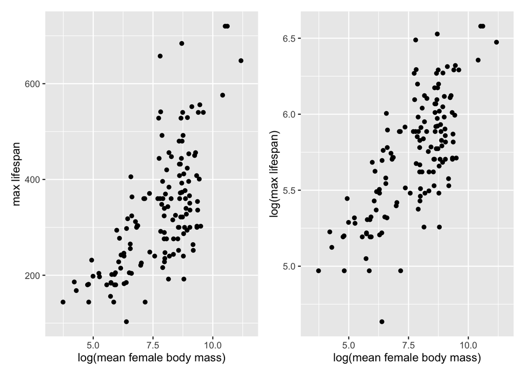

```r
p1 <- ggplot(d,aes(x=log(Body_mass_female_mean),y=MaxLongevity_m)) + geom_point(na.rm=TRUE) + ylab("max lifespan") +
  xlab("log(mean female body mass)")
p2 <- ggplot(d,aes(x=log(Body_mass_female_mean),y=log(MaxLongevity_m))) + geom_point(na.rm=TRUE) + ylab("log(max lifespan)") +
  xlab("log(mean female body mass)")
p1 + p2
```

Yes, they look more linear.

Running linear models on raw variables, one raw, one log-transformed, and both log transformed

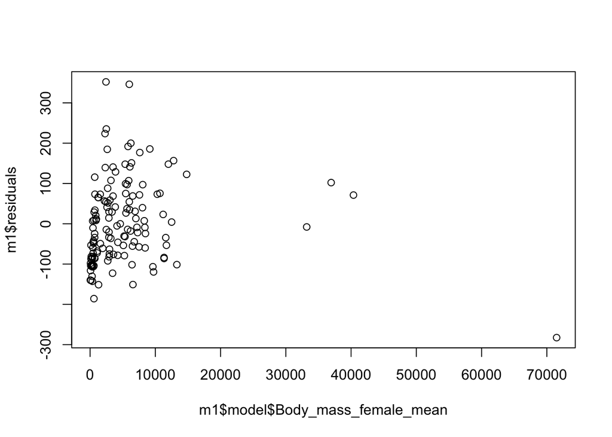

```r
m1 <- lm(MaxLongevity_m ~ Body_mass_female_mean,data=d)
m2 <- lm(MaxLongevity_m ~ log(Body_mass_female_mean),data=d)
m3 <- lm(log(MaxLongevity_m) ~ log(Body_mass_female_mean),data=d)

# plot residuals in relation to explanatory variable

plot(x=m1$model$Body_mass_female_mean,m1$residuals)
```

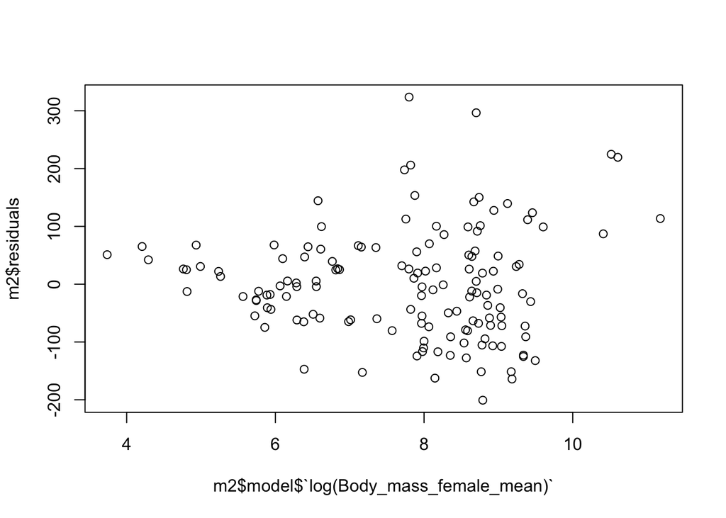

```r
plot(x=m2$model$`log(Body_mass_female_mean)`,m2$residuals)
```

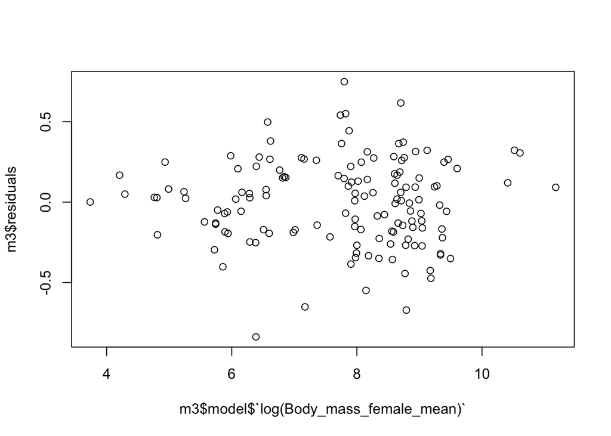

```r
plot(x=m3$model$`log(Body_mass_female_mean)`,m3$residuals)
```

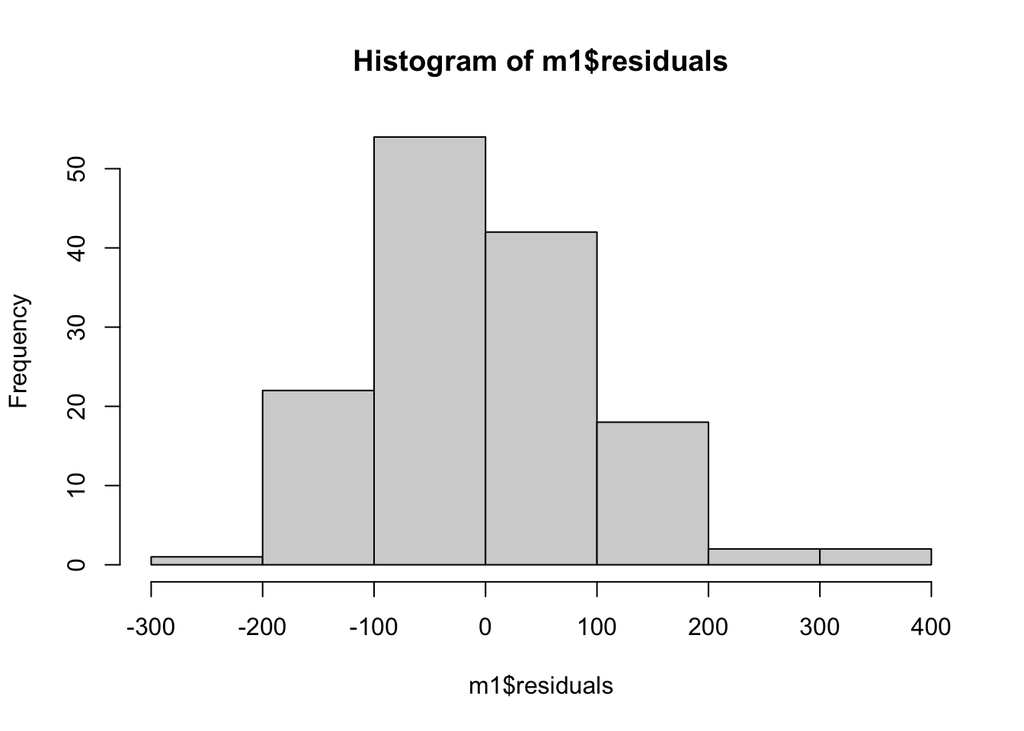

```r
hist(m1$residuals)
```

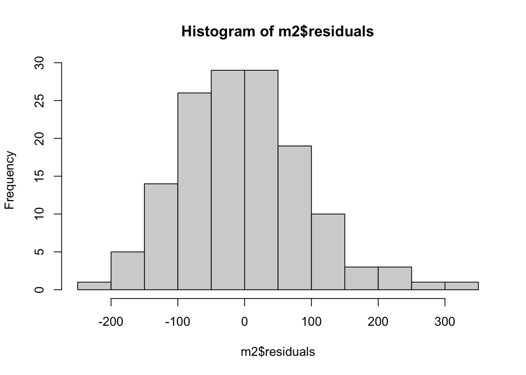

```r
hist(m2$residuals)
```

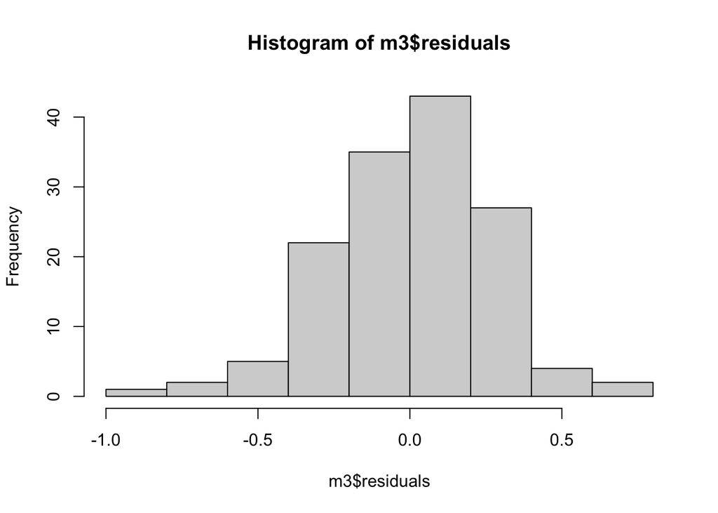

```r
hist(m3$residuals)
```

The distribution of residuals looks normal for model 3. There is some improvement of model 2 over the raw data but model 3 looks best.

Plotting QQ plots and looking at the residuals

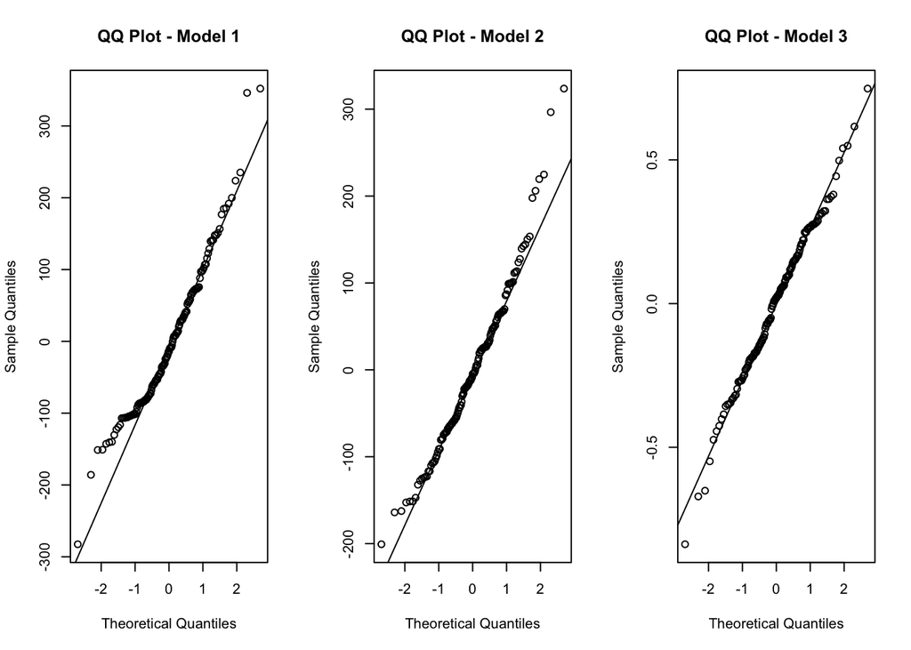

```r
# Q-Q plot of the three models
par(mfrow=c(1,3))
qqnorm(m1$residuals, main = "QQ Plot - Model 1")
qqline(m1$residuals, col = "black")
qqnorm(m2$residuals, main = "QQ Plot - Model 2")
qqline(m2$residuals, col = "black")
qqnorm(m3$residuals, main = "QQ Plot - Model 3")
qqline(m3$residuals, col = "black")
```

Again, model three looks best. The dots follow the normal line best. In model 1, the residuals deviate from the line very strongly at either end of the theoretical quantile range. In modeel 2, the deviation is more modest, but still present.

Running plot on the models.

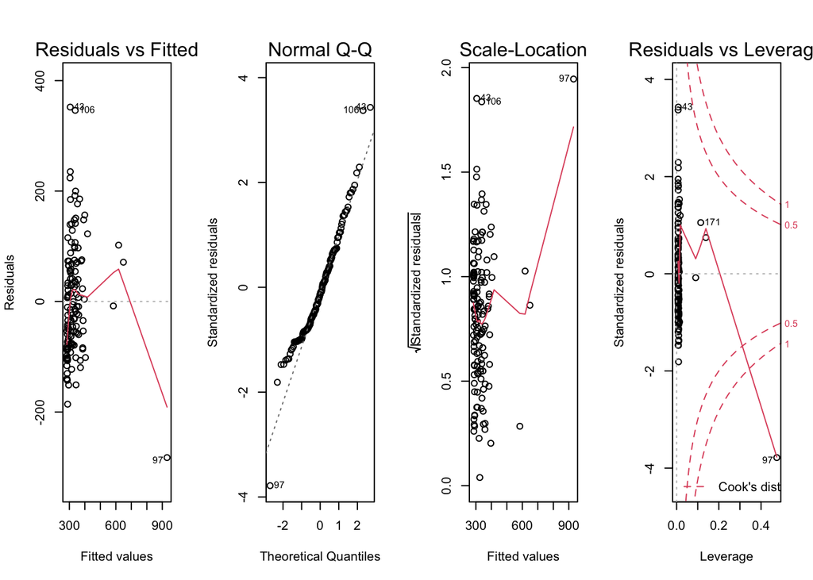

```r
par(mfrow=c(1,4))
plot(m1)
```

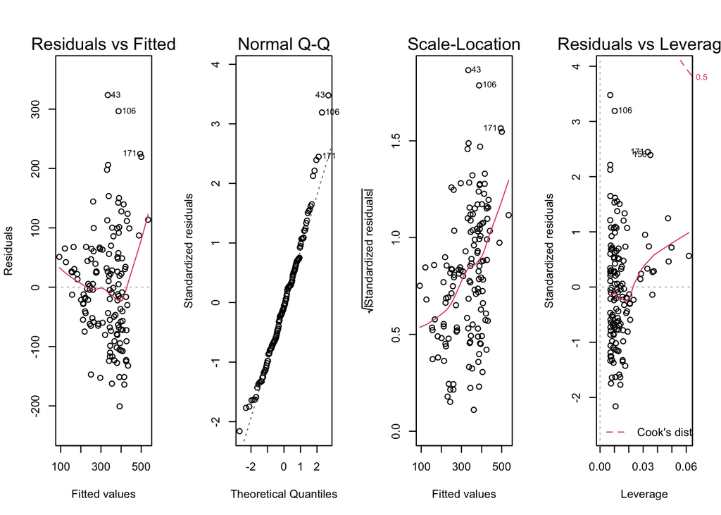

```r
plot(m2)
```

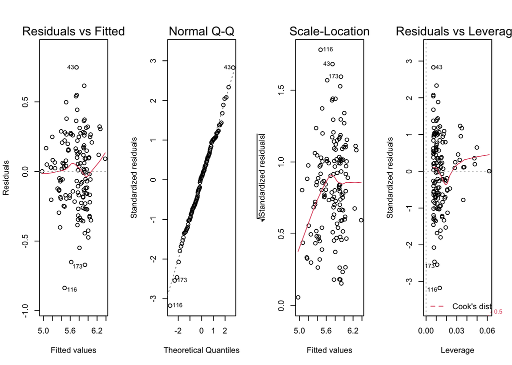

```r
plot(m3)
```

```r
shapiro.test(m1$residuals)
```

```
##
##  Shapiro-Wilk normality test
##
## data:  m1$residuals
## W = 0.96352, p-value = 0.0008238
```

```r
shapiro.test(m2$residuals)
```

```
##
##  Shapiro-Wilk normality test
##
## data:  m2$residuals
## W = 0.97515, p-value = 0.01131
```

```r
shapiro.test(m3$residuals)
```

```
##
##  Shapiro-Wilk normality test
##
## data:  m3$residuals
## W = 0.99319, p-value = 0.7403
```

The assumptions of linear model are not met for the first two models. The third model fits the assumptions best and should be used for examining the relationship between lifespan and body mass.

The shapiro-wilks test confirms what we see in the plots. We get a significant p-value for the first two plots which means that we reject the null hypothesis which states that the data come from a normally distributed population. Because this fails, we do not meet the assumptions of the linear modeling we are doing. The third model fails to reject the null and should be used for further analysis.